[figure not shown]

[OHI Science](http://ohi-science.org) | [Citation policy](https://github.com/OHI-Science/ohiprep/releases)

# Ocean Acidification pressure layer for OHI 2015

Compiled on Thu Nov 5 09:40:47 2015 by afflerbach

# 1 Summary

There are two parts to creating this layer:  
(1) Data prep to get raw data into the correct format: see dataprep.html  
(2) Creating the pressure layer for OHI which includes averaging across the most recent 5 years and rescaling values from 0 to 1 oa_create_layer_2015.html

For each year in the dataset provided, an average annual aragonite saturation state layer was created. Using these annual averages, a decadal average for both 1880-1889 and 2005-2014 was calculated.

# 2 Updates from previous assessment

Previous assessments did not have updated ocean acidification data after the 2012 global assessment.

This dataset provides more detailed temporal changes and includes more recent years of data. In addition, a biological reference point was set rather than the maximum value. All oceanic cells with values of Ω aragonite at or below 1 were assigned a value of 1. This threshold was chosen based on evidence from the literature that once undersaturation is reached (<=1), dissolution of CaCO3 occurs and negatively impacts biological processes including calcification.

# 3 Data

Raw data was provided by Woods Hole on December 16, 2014. This data is an update to the work done by [Feely et al. (2009)](http://www.tos.org/oceanography/archive/22-4_feely.pdf).

**Native Data Resolution**: 1 degree  
**Values**: Surface Ω aragonite saturation state  
**Time Range**: 1880-1889 and 2005-2014 (monthly data was provided for each year)  
**Format**: NetCDF

# 4 Methods

## 4.1 Overview

`dataprep.Rmd` created the following:

1. Calculates the historical global mean for the decade 1880-1889 (1 raster layer as output)
2. Calculates the annual mean for each of the 10 years in 2005-2014 (10 raster layers as output)

*NOTE: Interpolation was done in ArcGIS using OA_interpolation.py*

## 4.2 Detailed Methods

```r
#libraries

    library(raster)
    library(maps)
    library(RColorBrewer)

# set tmp directory

    tmpdir='~/big/R_raster_tmp'
    dir.create(tmpdir, showWarnings=F)
    rasterOptions(tmpdir=tmpdir)

# paths

    dir_N = c('Windows' = '//neptune.nceas.ucsb.edu/data_edit',
              'Darwin'  = '/Volumes/data_edit',
              'Linux'   = '/var/data/ohi')[[ Sys.info()[['sysname']] ]]

#set colors for plotting

    cols = rev(colorRampPalette(brewer.pal(11, 'Spectral'))(255)) # rainbow color scheme

#set root directory
require("knitr")

   opts_knit$set(root.dir = file.path(dir_N,'git-annex/globalprep/Pressures_OceanAcidification/v2015'))


# read in data

   hist_mean = raster(file.path(dir_N,'git-annex/globalprep/Pressures_OceanAcidification/v2015/working/global_oa_1880_1889_arag_mean_moll.tif')) # historical decadal mean of aragonite saturation state from 1880-1889

    files = list.files('working/annualmean_2005-2014/moll',full.names=TRUE,recursive=TRUE) # list the annual mean raster files for each year in 2005-2014

    #ocean is a raster with all land clipped out - at 1km with value of 1
    ocean = raster(file.path(dir_N,'model/GL-NCEAS-Halpern2008/tmp/ocean.tif'))
```

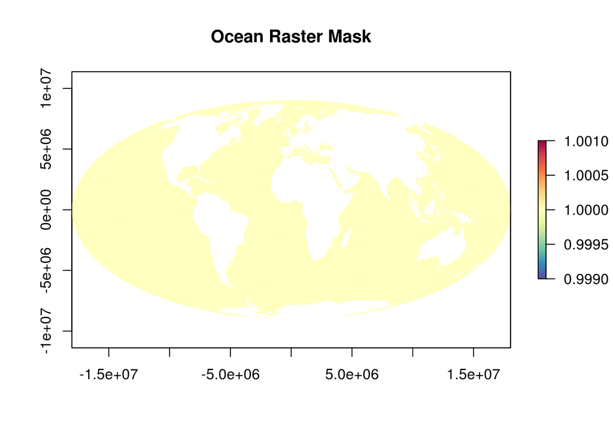

```r
    plot(ocean,col=cols,main='Ocean Raster Mask')
```

***

**(Step 1): Create function that subtracts annual mean from historical decadal mean and outputs raster to specified folder**

```r
    annual_change = function(file){

      yr = substr(file,56,59)         #use substr to grab the year out of the filename
      out = hist_mean - raster(file)  #subtract current from historical. Although this is counterintuitive, it results in the
                                      #correct scaling of values (higher values = more acidification)

#      writeRaster(out,filename=paste0('working/annualchange_2005-2014/difference_from_hist_mean_',yr,sep=""),format='GTiff',overwrite=T)

    }

  sapply(files,annual_change) # apply function across all files using sapply

  newfiles = list.files('working/annualchange_2005-2014',full.names=TRUE,recursive=TRUE) #list the new raster files (difference from historical mean)
```

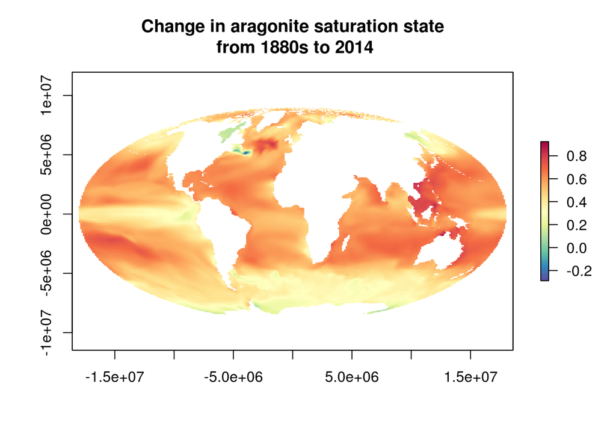

```r
plot(raster('working/annualchange_2005-2014/difference_from_hist_mean_2014.tif'),col=cols,main='Change in aragonite saturation state\n from 1880s to 2014')
```

**Step (2): Rescale values**

For each year between 2005 and 2014, look at the mean annual aragonite saturation state rasters (annualmean_2005-2014). All values at or below the threshold (<=1) are set to 1 (highest pressure value). All cells with aragonite saturation state values >1, will be scaled based on their change relative to historical levels (calculated above).

```r
    rescale = function(file){

        yr   = substr(file,56,59) #get year of file
        mean = raster(file)       #get annual mean aragonite raster for given year
        diff = raster(newfiles[substr(newfiles,58,61)==yr])  #get the change raster for same year (historical-current)
        mean[mean<=1]<-1    #all values at or less than 1 are given a value of 1
        mean[mean>1] = diff[mean>1]  # all cells with values greater than 1 are swapped out with their amount of change
        mean[mean<0]<-0   #all values less than 0 (indicating a decrease in acidity) are capped at 0

     #   writeRaster(mean,filename=paste0('working/annual_oa_rescaled/oa_rescaled_',yr,sep=""),format='GTiff',overwrite=T)

}

  sapply(files,rescale)

  rescaled = list.files('working/annual_oa_rescaled',full.names=T)
```

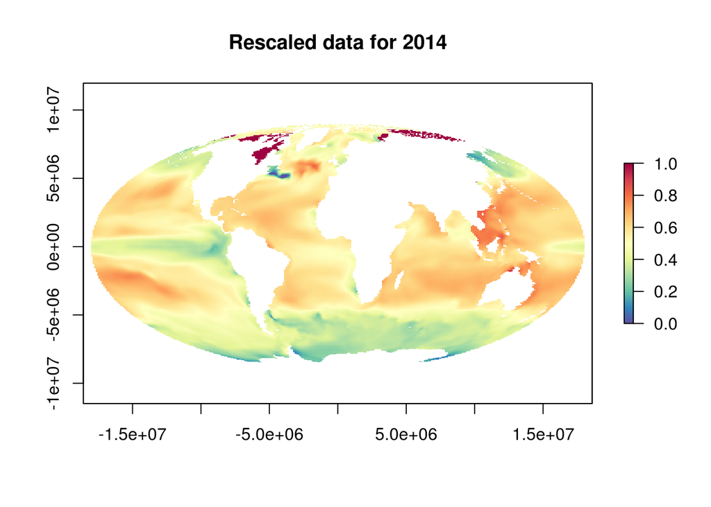

```r
  plot(raster('working/annual_oa_rescaled/oa_rescaled_2014.tif'),col=cols,main='Rescaled data for 2014')
```

***

**(Step 3): Resample to 1km**

```r
    resample = function(file){

        yr  = substr(file,40,43)
        r   = raster(file)
        out = raster::resample(r,ocean,method='ngb',progress='text') # resample r to the resolution of 'ocean' (~1km)

     #   writeRaster(out,filename=paste0('working/annual_oa_rescaled_1km/annual_oa_rescaled_1km_',yr,sep=''),format='GTiff',overwrite=T)
}

  sapply(rescaled,resample)
```

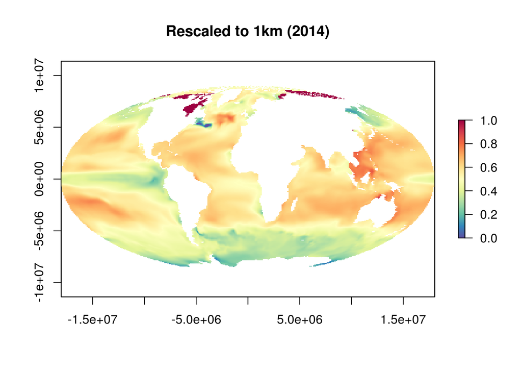

```r
  plot(raster('working/annual_oa_rescaled_1km/annual_oa_rescaled_1km_2014.tif'),col=cols,main='Rescaled to 1km (2014)')
```

***

**(Step 4): Interpolate to coast**

Interpolation to fill in NA cells with values of the nearest neighbor is done within the ‘OA_interpolation.py’ python script, which relies on arcpy (ArcGIS)

```r
interpolated = list.files('working/annual_oa_rescaled_1km_int',full.names=T)
```

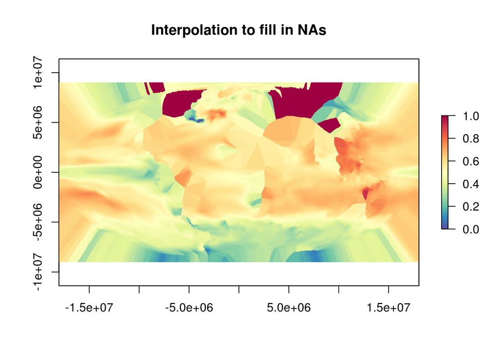

```r
plot(raster('working/annual_oa_rescaled_1km_int/annual_oa_rescaled_1km_2014_int.tif'),col=cols,main='Interpolation to fill in NAs')
```

***

**(Step 5): Clip out ocean**

Each interpolated raster needs to have all land cells clipped out. Using the ocean raster again, mask the interpolated rasters to select just those in the oceanic regions.

```r
    ocean_clip = function(file){

          yr  = substr(file,59,62)
          r   = raster(file)
          out = mask(r,ocean,progress='text')

   #       writeRaster(out,filename=paste0('output/annual_oa_rescaled_1km_int_clip_',yr,sep=''),format='GTiff',overwrite=T)

    }

    sapply(interpolated,ocean_clip)
```

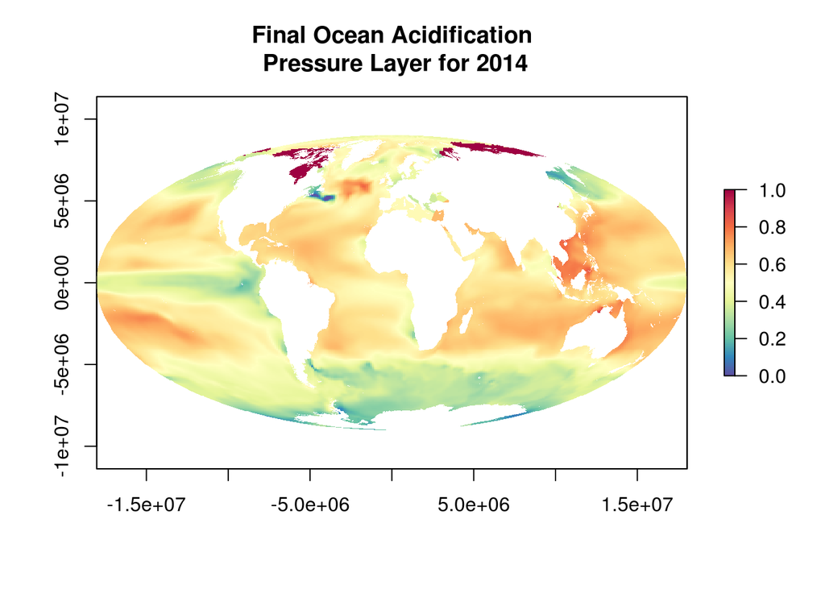

```r
plot(raster('output/annual_oa_rescaled_1km_int_clip_2014.tif'),col=cols,main='Final Ocean Acidification\n Pressure Layer for 2014')
```

***

**(Step 6): Create a raster showing what cells were interpolated**

All ten output OA rasters have the same cells interpolated

```r
    #original data rescaled and resampled, before interpolation

      r_1km = raster('working/annual_oa_rescaled_1km/annual_oa_rescaled_1km_2014.tif')

    #after interpolation, and after land clipped ou

      r_c = raster('output/annual_oa_rescaled_1km_int_clip_2014.tif')

    interp_cells = mask(r_c,r_1km,inverse=TRUE)
```

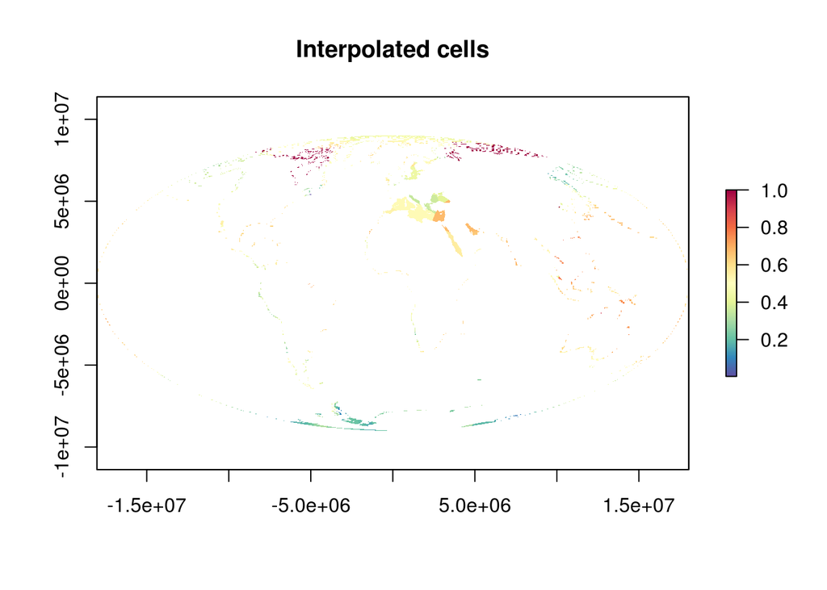

```r
    plot(raster('output/oa_interpolated_cells.tif'),col=cols,main='Interpolated cells')
```

**References**

Woods Hole Oceanographic Institution. 2014 update to data originally published in: Feely, R.A., S.C. Doney, and S.R. Cooley. 2009. Ocean acidification: Present conditions and future changes in a high-CO2 world. Oceanography 22(4):36–47